# Geoffrey Hinton · 1986 Nature 역전파 원논문 강의

**1986 역전파 · 편집 가능한 16:9 강의**

AI HISTORY · 원논문으로 배우는 딥러닝

김임환 · 설계특론

1986 NATURE · BACKPROPAGATION

# Geoffrey Hinton 왜 신경망을 포기하지 않았나?

1966년부터 신경망·기억에 관심을 가졌고, 심리학을 공부하며 ‘뇌는 어떻게 배우는가?’를 고민했습니다. 당시 부족했던 은닉층 학습법이 핵심 난제였습니다.

**1970**케임브리지 대학교 · 실험심리학 학사

**1978**에든버러 대학교 · 인공지능 박사

**1986**카네기멜런대 교수 재직 중 역전파 공동 논문

**1987 →**토론토대 연구 · 2024년 노벨 물리학상

연구의 출발점**“신경망 속 보이지 않는 층은 어떻게 학습할까?”**

GH

[figure not shown]

**Geoffrey E. Hinton**1947– · 신경망·표현학습 연구자사진: University of Toronto (웹 연결 시 표시)

출처: Hinton 공식 약력 · 인터뷰(GV, 2022) · Nature(1986) · NobelPrize.org(2024)

01 · WHY

NEURAL NETWORKS · 1986 CLASSIC PAPER

## 논문을 쓴 진짜 배경

힌튼의 관심은 ‘정답을 외우는 기계’가 아니라, 경험을 통해 내부 표현을 만드는 학습 원리였습니다.

HINTON 본인 인터뷰에서 확인되는 관심

“심리학을 이해하려면, 먼저 뇌가 어떻게 작동하는지 이해해야 한다.”

1960년대부터 신경망과 기억에 관심을 가졌지만, 당시에는 다층 연결의 가중치를 효과적으로 학습시키는 방법이 부족했습니다.

표현은 인터뷰의 한국어 요약이며, 논문의 직접 인용문은 아닙니다.

문제 1 · 표현의 학습

### 사람은 누가 특징을 알려주지 않아도 패턴을 배운다.

그렇다면 신경망의 은닉층도 유용한 특징을 스스로 찾아낼 수 있을까?

문제 2 · 책임의 배분

### 최종 예측이 틀렸을 때 어느 연결을 고쳐야 할까?

출력층뿐 아니라, 보이지 않는 은닉층의 가중치에도 수정 방향을 알려야 합니다.

한 줄 이해: 1986년 논문은 ‘은닉층에 학습 신호를 전달하는 방법’과 ‘그 결과 무엇을 배울 수 있는가’를 보여주었습니다.

출처: Hinton 공식 약력; GV, Geoffrey Hinton on the Exploration of Thought; Rumelhart et al., Nature 1986

02 · THE PAPER

NEURAL NETWORKS · 1986 CLASSIC PAPER

## 우리가 읽는 원논문: 단 4쪽의 전환점

Learning representations by back-propagating errors · Nature 323, 533–536 (1986.10.09)

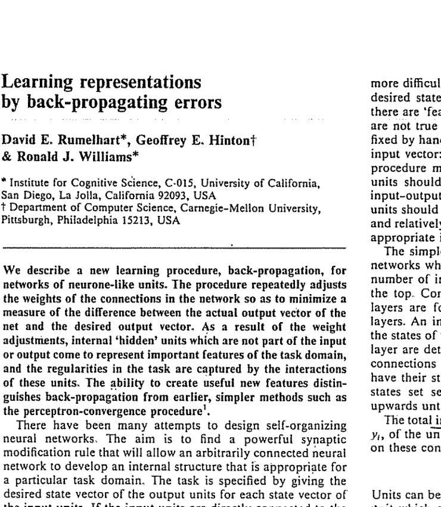

첨부된 1986년 Nature 원문 · 533쪽

저자 3인 · 공동 연구

### David E. Rumelhart Geoffrey E. Hinton Ronald J. Williams

당시 Hinton 소속: Carnegie-Mellon University

논문 초록의 핵심

### 출력 오류를 줄이도록 연결 가중치를 반복 수정하면, 은닉층이 문제 해결에 필요한 특징을 표현한다.

[Nature 논문 열기](https://doi.org/10.1038/323533a0)[Hinton 연구 목록](https://www.cs.toronto.edu/~hinton/backprop.html)

자료: 사용자가 업로드한 Nature 원문 PDF · DOI 10.1038/323533a0

03 · BEFORE 1986

NEURAL NETWORKS · 1986 CLASSIC PAPER

## 왜 당시 신경망은 어려움을 겪었을까?

핵심은 계산 자체보다 “여러 층을 어떻게 학습시킬 것인가”였습니다.

**1958**

### 퍼셉트론

Rosenblatt의 초기 학습형 신경망 연구

**1969**

### 한계 지적

Minsky와 Papert가 특정 퍼셉트론 구조의 표현 한계를 체계적으로 분석

**1970s**

### 은닉층 난제

다층 신경망은 표현력이 있지만 내부 가중치를 어떻게 바꿀지 어려움

**1986**

### 역전파 확산

출력 오차를 은닉층까지 전파하여 학습시키는 절차를 명확히 제시

### 오해하지 말 것

1969년에 ‘모든 신경망이 불가능하다’고 증명된 것은 아닙니다. 신경망 연구도 완전히 중단된 것은 아닙니다.

### 학생에게 던질 질문

“모델이 틀렸다는 사실만 알면, 수많은 연결 중 무엇을 얼마나 고쳐야 할까요?”

참조: Rosenblatt(1958/1961), Minsky & Papert(1969), Nature(1986); 역사적 해석을 위한 교육용 요약

04 · THE BASIC UNIT

NEURAL NETWORKS · 1986 CLASSIC PAPER

## 뉴런 하나는 ‘가중치를 가진 계산기’

입력값 × 중요도(가중치)를 합친 뒤, 활성화 함수로 출력을 만듭니다.

온도 x₁압력 x₂유량 x₃

× w₁× w₂× w₃

Σ

→

출력 y

y = f(w₁x₁ + w₂x₂ + w₃x₃ + b)

w: 각 입력의 영향력 · b: 기준값 조정 · f: 비선형 활성화

반도체 공정에 대입하면

### 온도와 압력 데이터를 보고 불량 가능성을 추정하는 계산 단위

단, 이 예시는 이해를 돕기 위한 가상 예시입니다. 논문의 원래 실험 데이터는 아닙니다.

학습이란?

### 처음에는 임의였던 가중치 w를 오류가 줄어드는 방향으로 바꾸는 과정

근거: Rumelhart et al.(1986) 뉴런의 활성화 및 가중치 학습 개념; 공정 사례는 교육용 예시

05 · XOR

NEURAL NETWORKS · 1986 CLASSIC PAPER

## 단층으로는 어려운 패턴: XOR

두 입력이 다를 때만 1. 한 개의 직선 경계로는 네 점을 정확히 분리할 수 없습니다.

### 진리표: 입력 두 개가 다르면 1

| A | B | 정답 |
| --- | --- | --- |
| 0 | 0 | 0 |
| 0 | 1 | 1 |
| 1 | 0 | 1 |
| 1 | 1 | 0 |

B ↑

0

1

1

0

A →

0과 1이 대각선으로 섞여 있습니다. 하나의 직선만으로는 나눌 수 없습니다.

해결 방향: 은닉층과 비선형 활성화를 넣으면 여러 경계를 조합해 XOR를 표현할 수 있습니다.

설명: XOR는 다층 신경망의 필요성을 보여주는 대표적 교육용 예시로, Nature(1986)의 중심 실험 자체는 아님

06 · HIDDEN LAYER

NEURAL NETWORKS · 1986 CLASSIC PAPER

## 해답의 핵심: 은닉층에도 가중치가 있다

입력 → 은닉층 → 출력으로 전달하면서 중간층이 단순 입력을 다른 표현으로 바꿉니다.

입력층 Input은닉층 Hidden출력층 Output

[figure not shown]

### 입력층

온도, 압력 같은 관측값을 전달

### 은닉층

관측값을 결합해 유용한 중간 특징 생성

### 출력층

최종 예측값을 만들어 정답과 비교

도식: 역전파의 일반적인 다층 신경망 개념을 교육 목적으로 단순화

07 · FORWARD PASS

NEURAL NETWORKS · 1986 CLASSIC PAPER

## 1단계 · 순전파: 우선 예측해 본다

순전파(Forward propagation)는 값을 입력층에서 출력층까지 계산하는 과정입니다.

01

### 입력 넣기

센서 데이터

온도, 압력 등이 모델로 들어옵니다.

→

02

### 중간 계산

은닉 특징 h

가중합과 비선형 함수를 여러 층에서 적용합니다.

→

03

### 예측 만들기

예측 ŷ = 0.30

이 예시에서는 불량일 확률 30%로 예측합니다.

### 아직 학습한 것은 아닙니다.

순전파는 현재 가중치로 정답을 ‘맞혀 보는’ 과정입니다. 학습하려면 정답과 비교해야 합니다.

숫자 및 센서 사례는 단계 이해를 위한 가상 데이터

08 · LOSS

NEURAL NETWORKS · 1986 CLASSIC PAPER

## 2단계 · 오차: 얼마나 틀렸는지 계산한다

정답이 1인데 0.30으로 예측했다면, 오차를 수치로 표현해야 합니다.

정답 y**1.00**

vs

예측 ŷ**0.30**

L = ½ × (1.00 − 0.30)² **= 0.245**

이 예시는 제곱오차(½ MSE 항)입니다. 분류에서는 교차엔트로피도 흔히 씁니다.

### 손실 함수(Loss)

모델의 예측이 틀린 정도를 숫자로 표현한 것. 값이 작을수록 이 기준에서 예측이 정답에 가까워집니다.

### 이제 남은 문제

손실값을 알았는데, 수천 개 가중치 중 어떤 것을 어떻게 수정해야 할까요?

교육용 계산: L = ½(ŷ−y)², y=1, ŷ=0.30 이면 L=0.245

09 · BACKWARD PASS

NEURAL NETWORKS · 1986 CLASSIC PAPER

## 3단계 · 역전파: 오차의 책임을 거슬러 올라간다

최종 오차가 어느 연결 때문에 얼마나 발생했는지 거꾸로 계산합니다.

입력층데이터

→

→

출력층예측

→

손실 L정답과 비교

순전파: 예측을 만드는 방향

역전파: 출력층의 영향 → 은닉층의 영향 → 앞쪽 가중치의 영향

← ← ←

### 중요한 핵심: 오류 자체가 뒤로 흐르는 것?

정확히는 연쇄법칙으로 계산한 손실의 기울기(gradient)가 뒤쪽 층에서 앞쪽 층으로 전달됩니다.

### 그 후

모든 가중치에 대해 ‘올리면 나아지는가, 내리면 나아지는가’를 계산하고 조금씩 조정합니다.

출처: Nature(1986) 역전파 계산과 기울기 기반 가중치 수정

10 · CHAIN RULE

NEURAL NETWORKS · 1986 CLASSIC PAPER

## 수식은 이 한 가지만 이해하면 됩니다

연쇄법칙: 여러 계산을 거친 최종 손실이 한 가중치의 변화에 얼마나 민감한지 계산하는 규칙입니다.

가중치 w → 중간값 h → 예측 ŷ → 손실 L

∂L/∂w = ∂L/∂ŷ × ∂ŷ/∂h × ∂h/∂w

한 가중치가 손실에 미치는 영향 = 각 단계의 변화율을 곱한 값

### 기울기 양수

w를 늘리면 손실이 커지는 방향 → w를 줄여 봅니다.

### 기울기 음수

w를 늘리면 손실이 작아지는 방향 → w를 늘려 봅니다.

### 최종 가중치 갱신

새 w = 이전 w − 학습률(η) × 기울기

학생에게는 편미분 계산보다 “출력 오류가 은닉층의 학습 방향으로 바뀐다”는 메시지를 먼저 전달하세요.

수식은 단순한 연쇄 구조 예시이며 실제 다층망은 모든 연결의 경로와 기여를 합산합니다.

11 · INTERACTIVE DEMO

NEURAL NETWORKS · 1986 CLASSIC PAPER

## 직접 눌러 보는 역전파 · 단 하나의 가중치

아래 숫자는 실습용 가상 데이터입니다. ‘한 번 학습’을 누르면 오차가 줄어드는 과정을 볼 수 있습니다.

입력**x = 1**

w = **0.0000**→

시그모이드 출력**0.5000**

목표 정답**1.0000**

학습 횟수**0**

기울기 ∂L/∂w**−0.1250**

손실 L**0.12500**

### 실습 규칙

ŷ = sigmoid(wx), L = ½(ŷ − 1)², 학습률 η = 1.0

각 반복은 순전파 → 기울기 계산 → 가중치 갱신 순서입니다.

### 관찰할 것

① 가중치는 커집니다. ② 예측은 1에 가까워집니다. ③ 손실은 점차 작아집니다.

실습: 단일 시그모이드 뉴런을 이용한 기울기 하강법 시뮬레이션; 원논문의 실험값과 무관

12 · ORIGINAL FIGURE 1

NEURAL NETWORKS · 1986 CLASSIC PAPER

## 논문 실험 ① 거울 대칭을 스스로 구별하다

원논문 Fig.1: 6개 입력을 가진 대칭 판별 문제에서 은닉 유닛이 유용한 가중치 패턴을 학습했습니다.

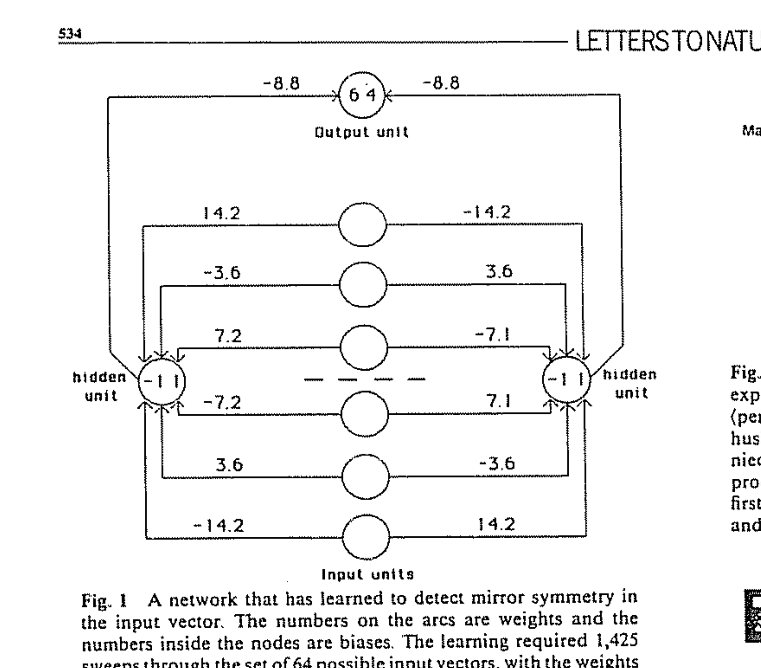

원논문 Fig.1 · 534쪽 · 입력 6개, 은닉 유닛 2개, 출력 유닛 1개

### 문제

6개의 이진 입력 패턴이 좌우 거울 대칭인지 구분해 보세요.

### 발견

훈련 후 연결 가중치들이 좌우 입력의 차이를 감지하는 구조를 갖게 되었습니다.

### 왜 중요한가?

‘대칭을 확인하는 규칙’을 은닉층에 사람이 직접 코딩하지 않아도, 학습이 내부 표현을 조직합니다.

원문: Nature 323, Fig.1, p.534 · 첨부 PDF에서 발췌

13 · ORIGINAL FIGURES 2–3

NEURAL NETWORKS · 1986 CLASSIC PAPER

## 논문 실험 ② 가족관계 속 ‘의미’를 학습하다

원논문은 가족 이름과 관계를 입력받아 연결된 사람을 예측하는 네트워크를 제시합니다.

[figure not shown]

Fig.2 · 구조가 유사한 두 가족 관계도

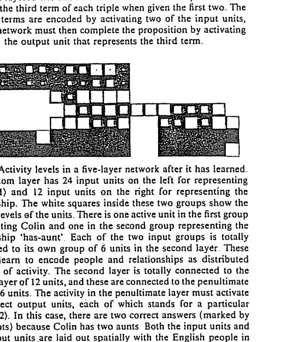

Fig.3 · 은닉층이 학습한 내부 활동 패턴

### 입력

사람 + 관계(예: 아버지, 어머니, 아들)

### 정답

그 관계에 해당하는 사람

### 중요한 결과

은닉층은 사람의 이름 자체만 외우지 않고, 공통 가족 구조를 활용할 수 있는 내부 표현을 형성했습니다.

원문: Nature 323, Figs.2–3, p.534 · 첨부 PDF에서 발췌

14 · ORIGINAL FIGURE 4

NEURAL NETWORKS · 1986 CLASSIC PAPER

## 은닉층은 ‘이름’이 아닌 ‘숨은 규칙’을 학습한다

원논문 Fig.4는 학습된 가중치가 단순 암기를 넘어 관계 구조를 담는다는 근거를 보여줍니다.

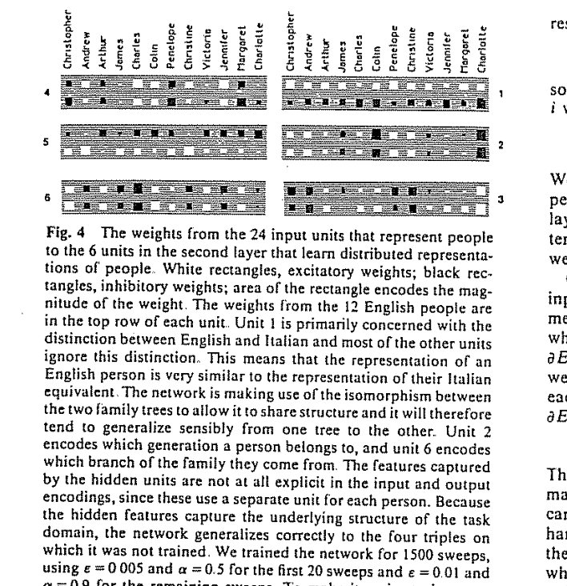

Fig.4 · 학습된 입력→은닉층 가중치 패턴

### 원논문의 해석

특정 은닉 유닛은 영국 가족/이탈리아 가족의 구별, 세대, 가족 내 가지(branch) 등과 관련된 구조를 표현했습니다.

### Distributed Representation

하나의 개념을 단일 뉴런 한 개가 아니라 여러 은닉 유닛의 활동 조합으로 표현합니다.

### 연구 기여의 핵심

역전파는 단지 ‘답을 맞히는 방법’이 아니라 ‘어떤 특징이 유용한지 학습시키는 방법’이었습니다.

원문: Nature 323, Fig.4, p.535 · 첨부 PDF에서 발췌

15 · CRITICAL READING

NEURAL NETWORKS · 1986 CLASSIC PAPER

## 이 논문이 증명한 것과, 증명하지 않은 것

역사적 의미는 매우 크지만 ‘역전파가 1986년에 처음 발명되었다’는 설명은 부정확합니다.

확인된 기여

### 다층망의 유용한 내부 표현을 학습

오류를 뒤로 전달해 은닉층의 가중치를 조정하고, 대칭 및 관계 표현 예시로 학습 결과를 보였습니다.

연결주의(connectionism) 연구 확산의 대표적인 이정표입니다.

해석상 주의

### 최초 발명 · 모든 문제 해결 · 뇌의 실제 학습 원리 입증 ≠ 아님

역방향 미분·가중치 학습의 선행 아이디어가 있었고, 이후에도 기울기 소실, 데이터, 계산자원 같은 문제가 남았습니다.

다층망이 모든 표 데이터에서 기존 머신러닝보다 낫다는 뜻도 아닙니다.

정확한 역사적 표현: 1986년 논문은 역전파 기반 다층 신경망 학습의 가능성과 표현학습의 장점을 설득력 있게 보여주고 널리 알렸습니다.

참조: Nature(1986) 본문·참고문헌; Hinton 공식 연구목록; 역사적 선행연구는 추가 학문적 맥락

16 · ENGINEERING APPLICATION

NEURAL NETWORKS · 1986 CLASSIC PAPER

## 반도체 공정 데이터에 적용하면 무엇이 달라질까?

이 장은 논문의 직접 실험이 아니라, 역전파의 원리를 설계특론 과제에 연결한 교육용 예시입니다.

공정 데이터

온도압력RF 전력가스 유량

→

은닉층 표현 학습

비선형 조합조건 간 상호작용잠재 패턴

→

예측 목표

Pass / Fail불량 확률

### 왜 신경망을 배우는가?

센서별 독립 효과뿐 아니라, 여러 공정 변수의 복잡한 조합을 학습할 수 있기 때문입니다.

### 현실의 검증 조건

무조건 신경망이 더 좋은 것은 아닙니다. 분리된 테스트셋, 불량 클래스 PR-AUC·Recall·F1, 데이터 누수 점검과 XGBoost 등의 기준 모델이 필요합니다.

강의 적용 예시: 반도체 센서 데이터 · 1986년 논문이 공정 데이터에서 우위를 검증했다는 뜻은 아님

17 · IMPACT & DISCUSSION

NEURAL NETWORKS · 1986 CLASSIC PAPER

## 1986 → 2012 → 오늘: AI의 큰 흐름

역전파 자체가 딥러닝의 모든 성공을 만든 것은 아닙니다. 학습 방법에 데이터·연산·구조 혁신이 더해졌습니다.

**1986**

### 학습 규칙

오류 역전파로 은닉층 표현 학습

**2012**

### 대규모 실증

AlexNet: ImageNet 2012 top-5 오류 15.3%, 차점 모델 26.2%

**2024**

### 역사적 인정

Hinton과 Hopfield 노벨 물리학상 수상

학생에게 남길 2가지 질문

### ① 왜 여러 층의 신경망은 단층 신경망보다 복잡한 관계를 배울 수 있을까?

### ② 순전파·손실·역전파를 반도체 공정 예측에 적용한다면 무엇부터 검증해야 할까?

[Nature 1986](https://www.nature.com/articles/323533a0)[Hinton 약력](https://www.cs.toronto.edu/~hinton/bio.html)[Hinton 인터뷰](https://podcast.gv.com/what-is-a-thought/)[AlexNet 2012](https://papers.nips.cc/paper_files/paper/2012/hash/c399862d3b9d6b76c8436e924a68c45b-Abstract.html)[노벨상 공식 기록](https://www.nobelprize.org/laureate/1038)

출처: Nature(1986); NeurIPS(2012); NobelPrize.org(2024) · 수업용 재구성

1 / 18

**현재 장 문장 편집**